# 격리된 장소 사이의 교류

## 연구 배경

소록도

낙생원

애락원

나란히 놓는 것만으로는 장소 사이의 관계가 설명되지 않음

주목하는 기록

이동과 방문간행물서신문예 활동

접근

연결을 미리 가정하지 않고,  
확인되는 관계를 쌓음

소록도, 낙생원, 애락원은 각각 격리와 차별의 역사를 지닌 장소입니다. 비슷한 시설과 경험을 나란히 놓는 것만으로는 장소 사이의 관계를 설명하기 어려워, 이동과 방문, 간행물, 서신, 문예 활동처럼 관계를 확인할 수 있는 기록에 주목했습니다. 연결을 미리 가정하지 않고 확인되는 관계를 쌓는 방식으로 진행합니다.

## 검토 자료: 오키나와 애락원 기관지 『愛楽』

[figure not shown]

[figure not shown]

제6호 · 文芸特集号

[figure not shown]

제7호

분석 대상 · 6·7호 수록 글

방문기순방기평론좌담회서신감사란원 일지편집후기문예

검토 대상은 미국 통치기 오키나와 애락원의 기관지 『愛楽』입니다. 분석 중인 제6호와 제7호는 1957년에 나왔고, 그 사이에 본토 의사 田尻가 약 4개월 체류했습니다. 3호부터 5호까지도 보유하고 있습니다.

## 6·7호 지면 구성과 관계 기록의 위치

기록·논설 감사란 문예 관계 기록 창작 속 언급

[figure not shown]

6호와 7호의 지면을 쪽 단위로 나열하고, 관계 기록이 나오는 쪽에 점을 찍었습니다. 7호는 앞쪽 기록·논설과 좌담회에 관계 기록이 모여 있고, 6호는 방문기와 감사란에 많습니다. 6호 창작 「焼土の女」의 지명은 관계에서 제외하고 빈 원으로 표시했습니다.

## 기록의 정리 기준

접촉

사람·물건·글의 실제 이동, 대면, 소속, 계약이 지면에 진술된 경우

방문, 기증, 서신, 선자

서술

필자가 다른 주체를 비교·요구·평가·언급한 경우 (접촉 여부와 별개)

평론의 타 요양소 인원 비교

제외

창작 속 인물·지명, 같은 지면에 함께 나온 것만으로는 관계로 보지 않음

확인 수준

명시 · 교차 확인 · 추정

비교에 쓰인 정보는 출처를 따로 추적

초기에는 의료 상황 비교가 중심이었지만, 그러면 교류의 경로가 뒤로 밀려서 누가 누구와 접촉했고 무엇이 어느 방향으로 전달되었는지를 먼저 정리했습니다. 이때 접촉과 서술을 나누었습니다. 평론에 다른 요양소와의 인원 비교가 나온다는 것은 그 정보가 쓰였다는 뜻이지, 필자의 방문이나 서신의 증거는 아닙니다. 소설 속 지명과 이동은 제외했고, 관계마다 확인 수준을 기록했습니다.

## 6호 감사란 (1956.8~1957.3)

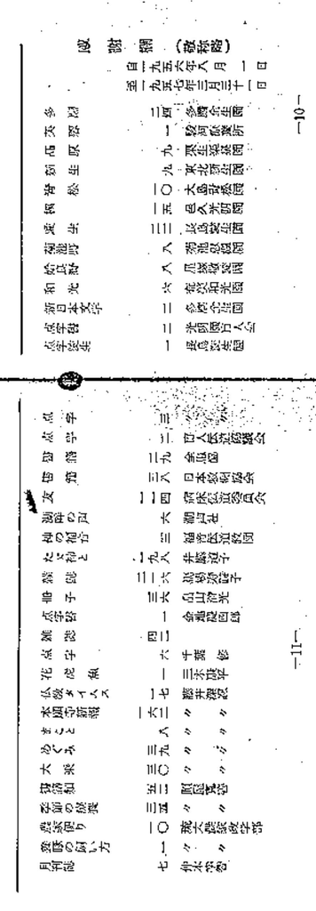

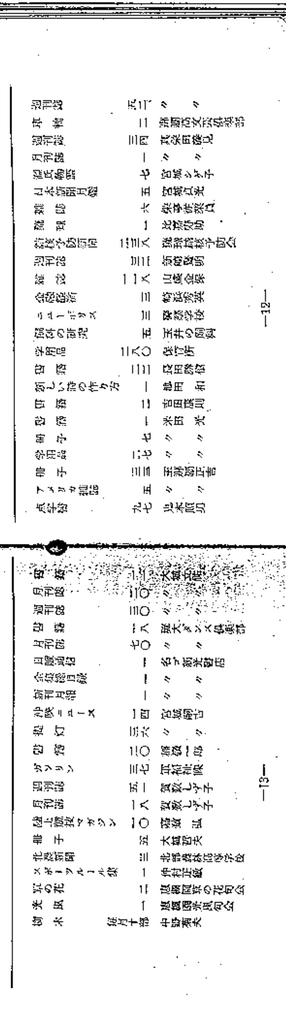

요양소 기관지 (부수)

16 / 82

요양소·요양소 내 단체가 보낸 항목

『新日本文学』 — 多磨全生園

『草の花』『光風』 — 恵楓園 句会

『樹木』 매달 10부 — 中野菊夫

『たゞ神と』 198 — 井藤道子

38부 — 日本〔救癩?〕協会

6호 감사란에는 1956년 8월부터 1957년 3월까지 받은 간행물과 물품이 품명, 수량, 발송처 순으로 실려 있습니다. 82항목 가운데 16항목이 요양소나 요양소 안의 단체가 보낸 것이고, 본토 요양소 기관지 10종이 보입니다. 이것은 애락원 쪽의 수령 기록이어서 상호 교환 여부는 아직 확인되지 않았습니다.

## 中野菊夫 관련 기재

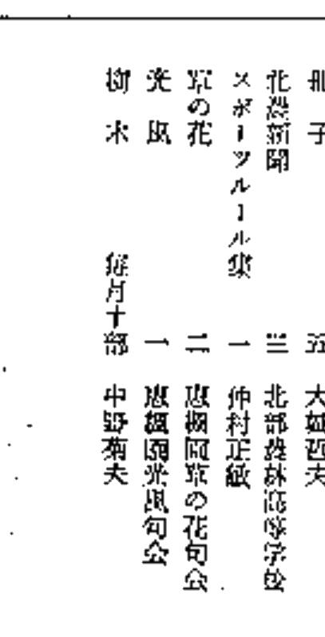

6호 · 감사란 13쪽

『樹木』  
매달 10부 기증

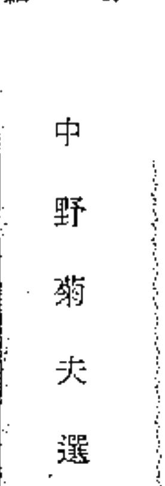

7호 · 가요란 22쪽

선자로 표기

미확인

원고 발송 주체와 선정 결과 전달 방식 활동 지속 기간 『樹木』 해당 시기 본문

中野菊夫는 6호 감사란에 『樹木』을 매달 10부 보낸 사람으로, 7호에는 가요란의 선자로 나옵니다. 원본에서 두 기록이 확인되면 같은 사람이 간행물 제공과 작품 선정에 함께 관여했다고 쓸 수 있습니다. 원고를 누가 보냈는지, 선정 결과를 어떻게 받았는지, 얼마나 이어졌는지는 확인되지 않았습니다. 『樹木』 본문은 일본근대문학관·국립국어연구소 소장 정보를 확인 중입니다.

## 田尻 관련 기재 대조

[figure not shown]

田尻에 관한 기재가 어느 글에 나오는지를 사항별로 대조했습니다. 류큐 정부의 초빙은 평론, 「別れの言葉」, 좌담회에 나오고, 출발과 내원 날짜, 자치회 간부와의 좌담은 6호 방문기에 있습니다. 귀환 뒤의 일은 부인이 쓴 「東京便り」에만 나옵니다. 편지에 나오는 방문객의 신원, 『愛楽』을 보낸 주체, 선물을 준 사람은 확인되지 않았습니다.

## 본토 기관지 측 기록

『愛楽』

본토 기관지

1957.07 6호  
방문기·편집후기

1957.11 7호  
평론·좌담회

8호  
좌담회 その二

1957.05·07·08  
『多磨』 沖縄だより

1957.09  
『多磨』 현악기 항목

1957.10~1958.03  
『多磨』 沖縄日記 1~6회

1939

1957~1958

1939.01  
『愛生』

1957년 방문 이전, 1939년 애락원 개원식 참석기 존재

국립한센병자료관의 기관지 목차 검색에서 田尻의 오키나와 관련 글이 본토 기관지에 실린 것을 확인했습니다. 『多磨』 1957년 5·7·8월호의 「沖縄だより」, 9월호의 현악기 전달 항목, 10월부터 이듬해 3월까지의 「沖縄日記」 6회입니다. 본문은 아직 확보하지 못했습니다. 그리고 1939년 1월 『愛生』에 田尻의 애락원 개원식 참석기가 있어서, 1957년 방문 이전의 관계도 기록되어 있습니다. 『愛楽』 8호의 좌담회 후속편도 확보해야 합니다.

## 연구 질문(안)

1957년 『愛楽』에 기록된 애락원의 대외 교류는  
누구를 매개로, 어떤 방식으로 이루어졌는가

01간행물·문예·방문과 서신으로 나누어 보는 틀이 적절한가

02교류의 기록과 격리의 조건을 어떻게 함께 읽을 것인가

03상대편 자료가 없는 관계를 어디까지 서술할 수 있는가

연구 질문은 아직 안입니다. 1957년 『愛楽』에 기록된 대외 교류가 누구를 매개로 어떤 방식으로 이루어졌는지를 묻고 있습니다. 이 틀과 읽는 방식에 대해 여러분의 의견을 듣고 싶습니다.

## 향후 작업

판독 확정

6·7호 원본 대조

기증 항목, 인명, 필자 신분, 선자 표기

후속 기록

『愛楽』 8호

「田尻先生を囲んで(その二)」

앞 시기

『愛楽』 3~5호

같은 기준으로 정리

상대편 자료

『多磨』 田尻 연재 본문

沖縄だより · 沖縄日記

문예 경로

『樹木』 · 中野菊夫

선평 활동

선행연구

교류의 상대·매개자·경로

어디까지 밝혔는지 검토

『愛楽』 1957 → 다른 시기의 오키나와 자료 → 한국 · 대만의 기록

먼저 6·7호 원본 대조로 기증 항목, 인명, 필자 신분, 선자 표기를 확정합니다. 이어서 8호의 좌담회 후속편과 보유한 3~5호를 같은 기준으로 정리하고, 상대편 자료로 『多磨』의 田尻 연재 본문과 『樹木』을 확보합니다. 선행연구는 교류의 상대, 매개자, 경로를 어디까지 밝혔는지를 기준으로 검토합니다. 이 기준을 다듬은 뒤 다른 시기의 오키나와 자료와 한국·대만의 기록으로 넓힐 계획입니다. 상대편 자료를 구하지 못한 관계는 『愛楽』에 명시된 범위까지만 다루겠습니다.

[figure not shown]